# partyGames

A simulation package for PHS 7045

Kline DuBose

## Introduction

The purpose of this package is to simulate various types of games of chance.

For this project, I mainly focused on the “White Elephant”/ Party Present game.

## Game Explanation

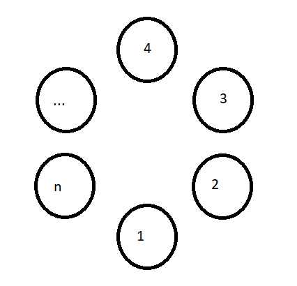

White Elephant Example

## Coin Example

The basic function run once is call`leftRightElephant`. It asks for the number of people playing and the probability of heads on a coin flip.

```r
leftRightElephant(15, 0.5) # Fair Coin
```

```
$moves
 [1] -1 -1 -1  1 -1 -1  1 -1  1 -1 -1  1 -1 -1 -1

$winner
[1] 9
```

Negative numbers indicate the present moving to the left and positive numbers indicate the present moving to the right . . .

```r
leftRightElephant(15, 0.7) # Unfair Coin
```

```
$moves
 [1] -1 -1 -1 -1 -1 -1 -1  1 -1 -1  1 -1 -1 -1  1

$winner
[1] 7
```

## Two - Coin Example

It also simulates a variation of the game using two coins in a function called `twoCoinElephant`

```r
twoCoinElephant(15, 0.3, 0.7)
```

```
$moves
 [1] -1 -1 -1  1 -1 -1 -1 -1 -1  1  1  1  1 -1  1

$winner
[1] 13
```

## Dice Example

Another variation uses dice.

```r
dieElephant(15, 6, 1) # One six-sided dice
```

```
$moves
 [1] 5 6 2 2 6 1 4 3 4 3 3 4 5 5 5

$winner
[1] 14
```

```r
dieElephant(15, 4, 2) # Sum of two four-sided dice
```

```
$moves
 [1] 2 5 7 6 5 7 6 3 2 5 6 5 5 4 3

$winner
[1] 12
```

## Other Functions

Other variations on the game include a combination of:

1. Using one coin and dice
2. Using two coins and dice

```r
lrDieElephant(15, 0.5, 6, 2) # One fair coin, two six-sided dice
```

```
$moves
 [1]  -8  -5  -6   3   8  -8  -9  12 -10   8  -5   7  -7  -6   7

$winner
[1] 12
```

```r
twoCoinDieElephant(15, 0.3, 0.7, 20, 1) # Two unfair coins, one twenty-sided dice
```

```
$moves
 [1]   5  16  10  -9   5  15  17  -9  10 -15  12  -7  17 -20  -6

$winner
[1] 12
```

## Simulation

The package can also simulate many instances of the game using `simulateElephant` and summarizes them using `summaryElephant`.

```r
# 1500 games with 15 people in it.
#One fair coin, one unfair coin.
#Two six-sided dice.
games <- simulateElephant(15, dice = TRUE, coins = 2,
                 pheads = 0.5, pheads2 = 0.7,
                 iter = 1500,
                 sides = 6, numDice = 2)
class(games)
```

```
[1] "elphList" "list"
```

## Simulation (cont.)

```r
# Returns two tables with counts of which seat won and number of times
# Each move was made
games.summary <- summaryElephant(games)
games.summary
```

```
$winner
winner
  1   2   3   4   5   6   7   8   9  10  11  12  13  14  15
106  87  90 102  98 106  97 107  98 111  96  99 105  93 105

$moves
moves
 -12  -11  -10   -9   -8   -7   -6   -5   -4   -3   -2    2    3    4    5    6
 365  745 1102 1454 1835 2232 1923 1492 1033  755  362  228  497  771  991 1236
   7    8    9   10   11   12
1602 1282 1022  815  510  248

attr(,"class")
[1] "elphSum" "list"
```

## Barplot

The function `plotElephant` displays a barplot showing the distribution of the winning barplot.

```r
plotElephant(games) # Using "elphList"
```

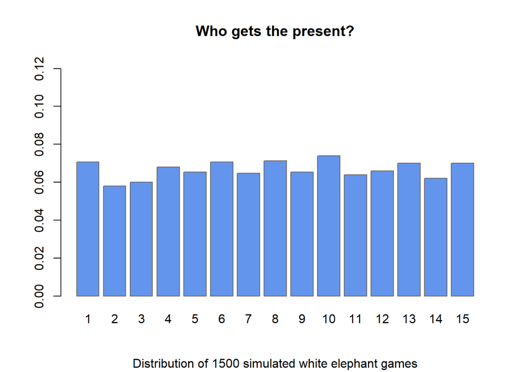

## Barplot (cont.)

```r
plotElephant(games.summary) # Using "elphSum"
```

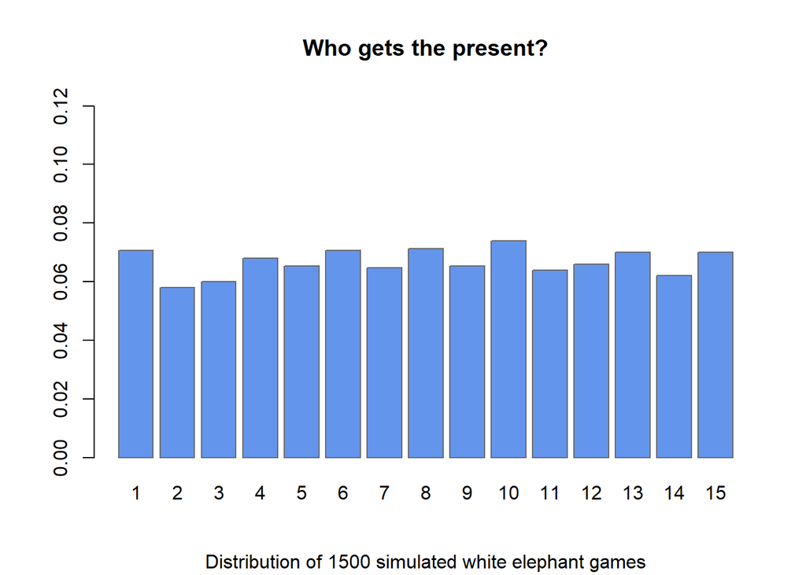